# Lynk&Co01舆情报告-W18_APP测试

Kevin

2019年5月9日

##### **领克汽车公关部**

#### **数据基本情况**

> 分析报告时间：2019年4月28日-2019年5月5日，共监测6,035条新闻报道，2,423条论坛帖子；

> 车型：领克 01、CR-V、奥迪Q3、途观L、RAV4、探岳、途岳；

> 媒体类型：网络新闻、手机新闻、微信、问答、视频、论坛、微博、平面（电子版）；

|  | 媒体平台 | CR.V | RAV4 | 奥迪Q3 | 领克01 | 探岳 | 途观L | 途岳 | 总计 |
| --- | --- | --- | --- | --- | --- | --- | --- | --- | --- |
| 1 | 网络新闻 | 655 | 597 | 873 | 240 | 552 | 649 | 367 | 3933 |
| 2 | 论坛 | 539 | 395 | 148 | 441 | 267 | 446 | 187 | 2423 |
| 3 | 手机新闻 | 392 | 311 | 210 | 150 | 151 | 264 | 137 | 1615 |
| 4 | 微博 | 0 | 0 | 0 | 354 | 0 | 0 | 0 | 354 |
| 5 | 微信 | 42 | 19 | 21 | 7 | 11 | 24 | 9 | 133 |
| 6 | Total | 1628 | 1322 | 1252 | 1192 | 981 | 1383 | 700 | 8458 |

#### **舆情概要**

##### **领克01**

- 本周领克01媒体声量排名第五，论坛声量排名第三，媒体下降57.2% ，论坛下降19.7%
- 本周领克01的热点是与沃尔沃XC40竞品对比，稿件[《国产沃尔沃XC40本月上市，同平台的领克01压力山大！》](https://baijiahao.baidu.com/s?id=1632604634665460198&wfr=spider&for=pc)内容被大量发布
- 论坛负面占比为9.8%%，比上周有所下降，负面集中在车机系统升级问题，动力变弱、故障灯亮等
- 车黑论坛账号和自媒体均为2个，攻击点集中在恶意攻击

#### **奥迪Q3**

- 本周奥迪Q3的热点是新旧款对比，稿件[《颜值显著提升/尺寸明显增加国产奥迪Q3新老对比》](http://news.bitauto.com/hao/wenzhang/30090628)被大量发布

#### **CR-V**

- 本周CRV的热点是被RS-5对比，稿件[《13万对比20万？新宝骏RS-5能赢CRV底气何在？》](https://www.iautos.cn/news/112214.html)被大量发布

#### **RAV4**

- 本周RAV4热点是新RAV4产品风格变化，稿件[《暖男变硬汉，全新RAV4为何如此“性情大变”？》](https://baijiahao.baidu.com/s?id=1632260759794376766&wfr=spider&for=pc)被大量发布

#### **途观L**

- 本周途观L的热点被自由光绑定对比，稿件[《新款自由光叫板途观L，动力越猛就越适合家用》](http://www.sohu.com/a/310941828_154499)被大量发布

### **1、领克01本周百度指数趋势**

|  | date | sample | value |
| --- | --- | --- | --- |
| 1 | 4月28日 | lynk01 | 4,327 |
| 2 | 4月29日 | lynk01 | 4,003 |
| 3 | 4月30日 | lynk01 | 4,253 |
| 4 | 5月1日 | lynk01 | 4,795 |
| 5 | 5月2日 | lynk01 | 4,961 |
| 6 | 5月3日 | lynk01 | 5,071 |
| 7 | 5月4日 | lynk01 | 5,285 |
| 8 | 5月5日 | lynk01 | 4,825 |
| 9 | 5月6日 | lynk01 | 4,533 |

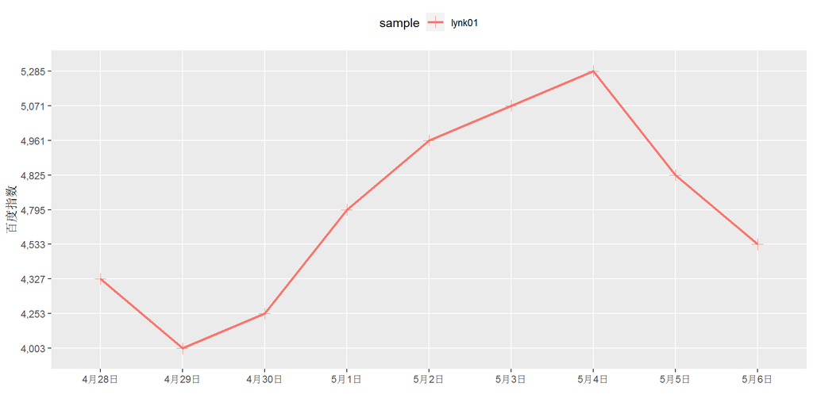

### **2、领克01微信指数传播趋势分析**

|  | date | sample | value |
| --- | --- | --- | --- |
| 1 | 4月28日 | 领克01 | 52284 |
| 2 | 4月29日 | 领克01 | 53284 |
| 3 | 4月30日 | 领克01 | 53073 |
| 4 | 5月1日 | 领克01 | 54304 |
| 5 | 5月2日 | 领克01 | 51951 |
| 6 | 5月3日 | 领克01 | 76542 |
| 7 | 5月4日 | 领克01 | 73051 |
| 8 | 5月5日 | 领克01 | 66008 |

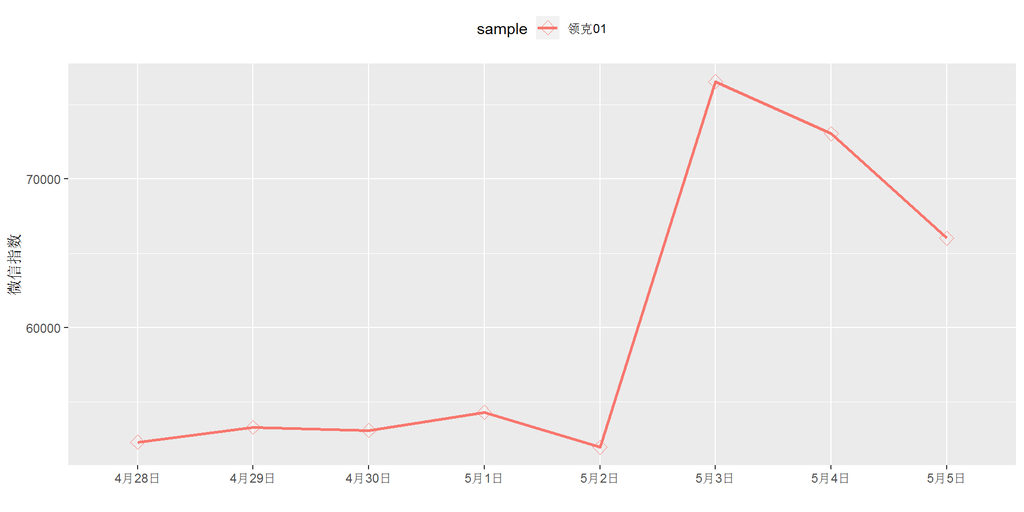

### **3、百度指数本竞品对比分析**

|  | 日期 | 领克01 | CRV | 奥迪Q3 | 探岳 |
| --- | --- | --- | --- | --- | --- |
| 1 | 4月28日 | 4327 | 4238 | 7963 | 3545 |
| 2 | 4月29日 | 4003 | 4277 | 7604 | 3585 |
| 3 | 4月30日 | 4253 | 3908 | 7757 | 3363 |
| 4 | 5月1日 | 4795 | 4021 | 8792 | 3678 |
| 5 | 5月2日 | 4961 | 4412 | 9115 | 3860 |
| 6 | 5月3日 | 5071 | 4619 | 9174 | 4310 |
| 7 | 5月4日 | 5285 | 4655 | 9440 | 4051 |
| 8 | 5月5日 | 4825 | 4437 | 8913 | 3963 |
| 9 | 5月6日 | 4,533 | 3,994 | 8,747 | 3,659 |

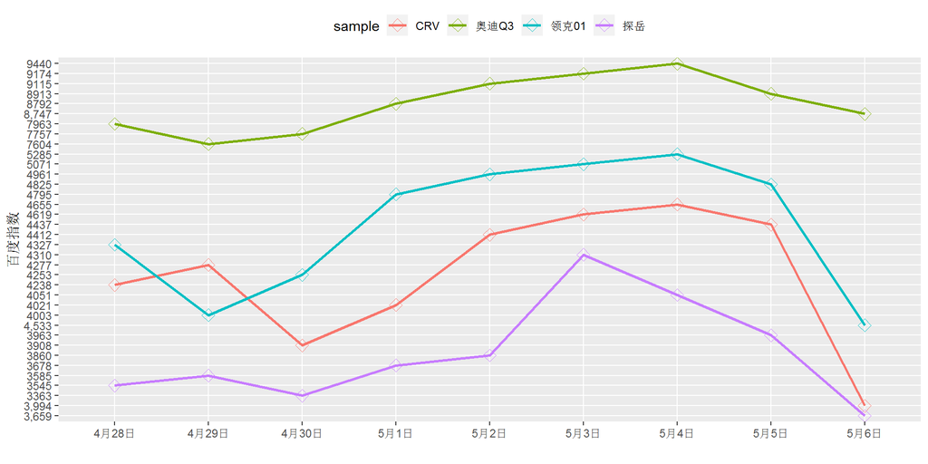

### **4、微信指数本竞品对比分析**

|  | 日期 | 领克01 | 奥迪Q3 | 探岳 | CRV |
| --- | --- | --- | --- | --- | --- |
| 1 | 4月28日 | 52284 | 113475 | 83598 | 380740 |
| 2 | 4月29日 | 53284 | 115846 | 89080 | 401658 |
| 3 | 4月30日 | 53073 | 117769 | 73103 | 345842 |
| 4 | 5月1日 | 54304 | 96092 | 92064 | 365650 |
| 5 | 5月2日 | 51951 | 97243 | 99354 | 372132 |
| 6 | 5月3日 | 76542 | 112718 | 89346 | 376316 |
| 7 | 5月4日 | 73051 | 113804 | 88214 | 441924 |
| 8 | 5月5日 | 66008 | 164606 | 94460 | 466948 |

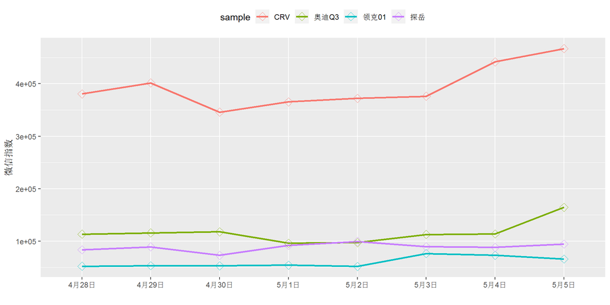

### **5、领克01本竞品媒体传播趋势对比**

|  | 行标签 | CRV | RAV4 | 奥迪Q3 | 探岳 | 途观L | 领克01 | 途岳 |
| --- | --- | --- | --- | --- | --- | --- | --- | --- |
| 1 | 2019/4/28 | 197 | 121 | 196 | 82 | 105 | 56 | 106 |
| 2 | 2019/4/29 | 169 | 170 | 184 | 132 | 163 | 112 | 76 |
| 3 | 2019/4/30 | 223 | 159 | 241 | 150 | 212 | 86 | 112 |
| 4 | 2019/5/1 | 82 | 106 | 82 | 46 | 86 | 63 | 48 |
| 5 | 2019/5/2 | 86 | 90 | 78 | 52 | 70 | 107 | 35 |
| 6 | 2019/5/3 | 83 | 107 | 66 | 43 | 117 | 92 | 32 |
| 7 | 2019/5/4 | 96 | 79 | 102 | 54 | 89 | 149 | 39 |
| 8 | 2019/5/5 | 153 | 95 | 155 | 155 | 95 | 86 | 65 |

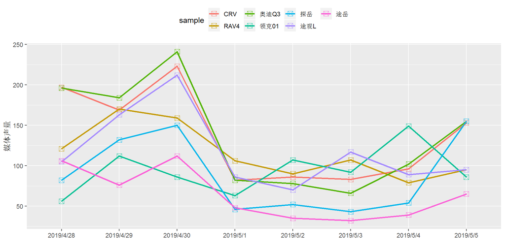

### **6、领克01本竞品论坛传播趋势对比**

|  | 日期 | CRV | RAV4 | 奥迪Q3 | 探岳 | 途观L | 领克01 | 途岳 |
| --- | --- | --- | --- | --- | --- | --- | --- | --- |
| 1 | 2019/4/28 | 46 | 46 | 10 | 26 | 48 | 57 | 17 |
| 2 | 2019/4/29 | 90 | 59 | 23 | 36 | 72 | 75 | 28 |
| 3 | 2019/4/30 | 77 | 54 | 21 | 55 | 74 | 72 | 32 |
| 4 | 2019/5/1 | 66 | 53 | 17 | 21 | 48 | 47 | 24 |
| 5 | 2019/5/2 | 73 | 34 | 22 | 38 | 44 | 54 | 20 |
| 6 | 2019/5/3 | 87 | 52 | 21 | 29 | 63 | 43 | 17 |
| 7 | 2019/5/4 | 70 | 66 | 15 | 47 | 64 | 62 | 28 |
| 8 | 2019/5/5 | 30 | 31 | 19 | 15 | 33 | 31 | 21 |

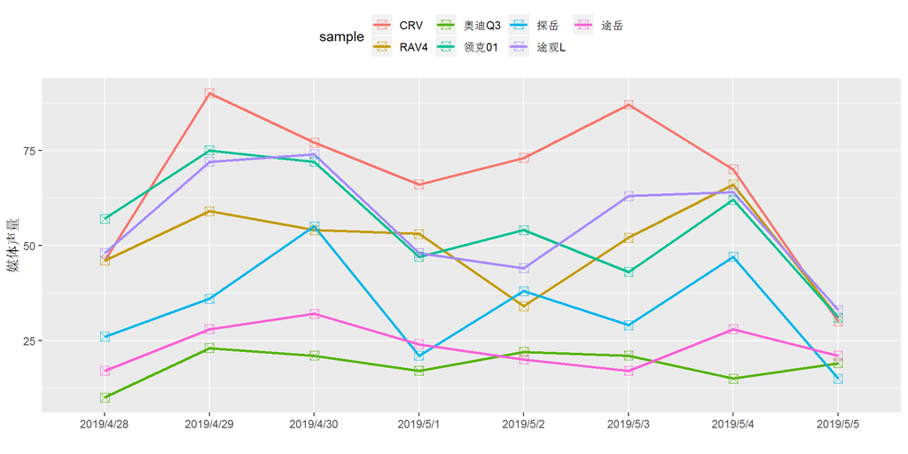

### **7、竞品提及**

#### **7.1-领克01媒体提及竞品**

|  | 竞品 | 上周 | 本周 |
| --- | --- | --- | --- |
| 1 | 途观L | 3 | 1 |
| 2 | CR-V | 5 | 5 |
| 3 | 奥迪Q3 | 12 | 6 |

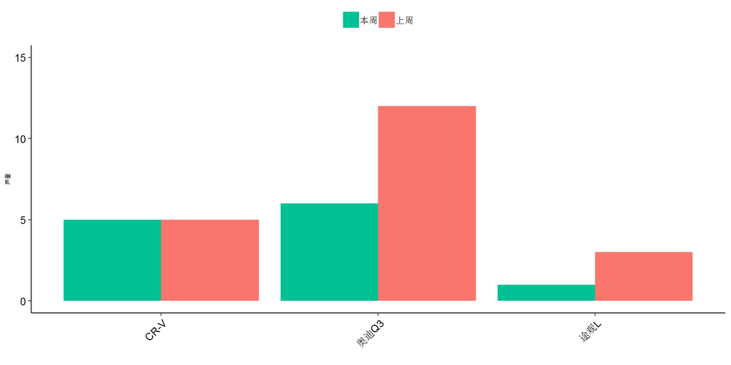

#### **7.2-竞品提及领克01频次**

|  | 竞品 | 上周 | 本周 |
| --- | --- | --- | --- |
| 1 | 途观L | 1 | 0 |
| 2 | CR-V | 12 | 4 |
| 3 | 奥迪Q3 | 20 | 5 |

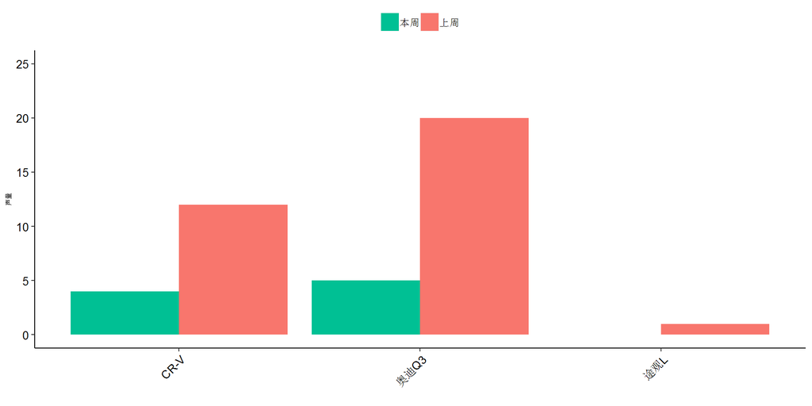

### **8、领克01本竞品18周声量对比**

|  | 车型 | 媒体 | 论坛 |
| --- | --- | --- | --- |
| 1 | 奥迪Q3 | 1,104 | 148 |
| 2 | CR-V | 1,089 | 539 |
| 3 | 途观L | 937 | 446 |
| 4 | RAV4 | 927 | 395 |
| 5 | 领克01 | 751 | 441 |
| 6 | 探岳 | 714 | 267 |
| 7 | 途岳 | 513 | 187 |

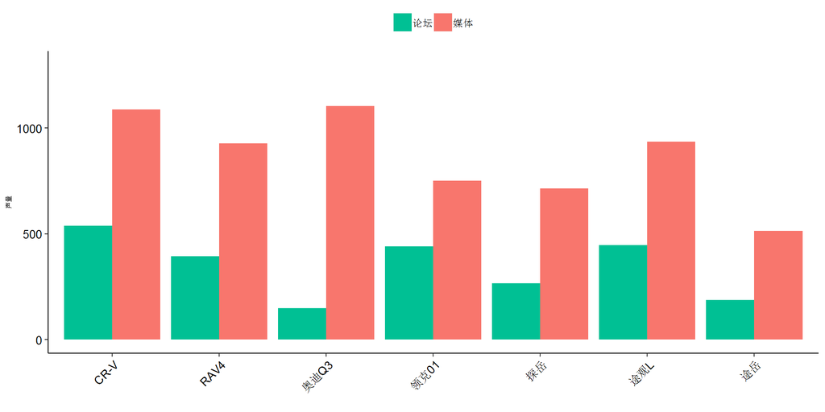

### **9、领克01正负面占比**

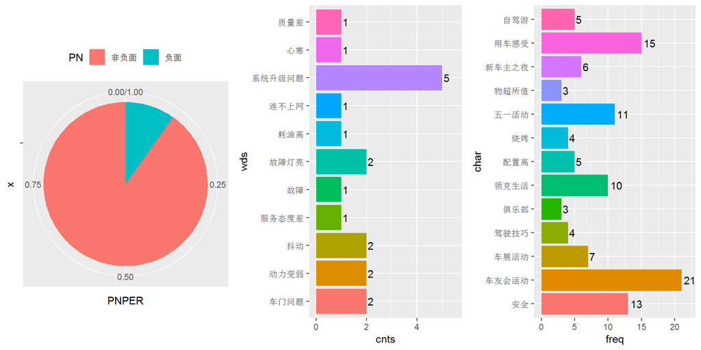

|  | PN | PNPER |
| --- | --- | --- |
| 1 | 负面 | 0.098 |
| 2 | 非负面 | 0.902 |

|  | wds | cnts |
| --- | --- | --- |
| 1 | 系统升级问题 | 5 |
| 2 | 动力变弱 | 2 |
| 3 | 故障灯亮 | 2 |
| 4 | 抖动 | 2 |
| 5 | 车门问题 | 2 |
| 6 | 连不上网 | 1 |
| 7 | 心寒 | 1 |
| 8 | 耗油高 | 1 |
| 9 | 服务态度差 | 1 |
| 10 | 故障 | 1 |

[output cut: 1 more lines]

|  | char | freq |
| --- | --- | --- |
| 1 | 车友会活动 | 21 |
| 2 | 用车感受 | 15 |
| 3 | 安全 | 13 |
| 4 | 五一活动 | 11 |
| 5 | 领克生活 | 10 |
| 6 | 车展活动 | 7 |
| 7 | 新车主之夜 | 6 |
| 8 | 自驾游 | 5 |
| 9 | 配置高 | 5 |
| 10 | 驾驶技巧 | 4 |

[output cut: 3 more lines]